# Distance analyses

WS 2016/17

## Prerequisites

## setwd, library, data, cleaning

```r
setwd("YOUR-PATH")
```

```r
raw_data <- read.table(file = "data/FS_UTM.csv",
                       header = TRUE,
                       sep = ";",
                       stringsAsFactors = FALSE,
                       quote = "")

## check for issues/problems
## str(raw_data)
## apply(X=raw_data[,4:20], MARGIN = 2, FUN=function(x){x[x>1]})
raw_data$settlement[raw_data$settlement > 1] <- 1

library(sp)
sites <- raw_data[(raw_data$settlement == 1 & raw_data$iron.age == 1),]
coordinates(sites) <- ~xUTM+yUTM
proj4string(sites) <- CRS("+init=epsg:32634")
```

## Distance analyses in geographic space

- abstract concept: can be measured in meters, time, money, strangeness, …
- influence interactions

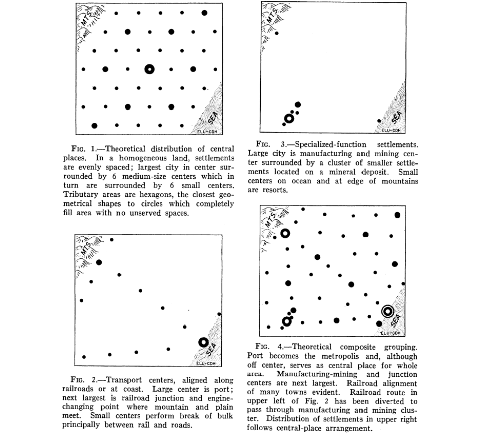

## Distance analyses in geographic space

1. straight/ direct
   - Euclidean distance
   - "As the crow flies"
   - "In a beeline"
   - geodesic distance
   - great-circle distance
2. not direct/ random
   - random walk
   - "Drunkard's Walk"

## Distance analyses in geographic space

\[d(i,j) = \sqrt{(x_i-x_j)^2 + (y_i-y_j)^2}\]

## Distance analyses in geographic space

Distance between points using Euclidean distance using package `rgeos`

```r
library(rgeos)
ed <- gDistance(spgeom1 = sites,
                byid = TRUE)
str(ed)
```

```
##  num [1:66, 1:66] 0 41669 57871 73645 74194 ...
##  - attr(*, "dimnames")=List of 2
##   ..$ : chr [1:66] "2" "22" "39" "53" ...
##   ..$ : chr [1:66] "2" "22" "39" "53" ...
```

```r
dim(ed)
```

```
## [1] 66 66
```

```r
head(ed[1,])
```

```
##        2       22       39       53       54       63
##     0.00 41668.60 57871.43 73644.50 74193.66 70688.26
```

Can you imagine the structure if the `ed` object?

## Distance analyses in geographic space

```r
min(ed)
```

```
## [1] 0
```

```r
round(data.frame(min = min(ed[ed>0]),
                 max = max(ed[ed>0]),
                 mean = mean(ed[ed>0]),
                 median = median(ed[ed>0])
                 ),
      2)
```

```
##    min      max     mean   median
## 1 1.73 225805.2 83029.08 79254.88
```

## Distance analyses in geographic space

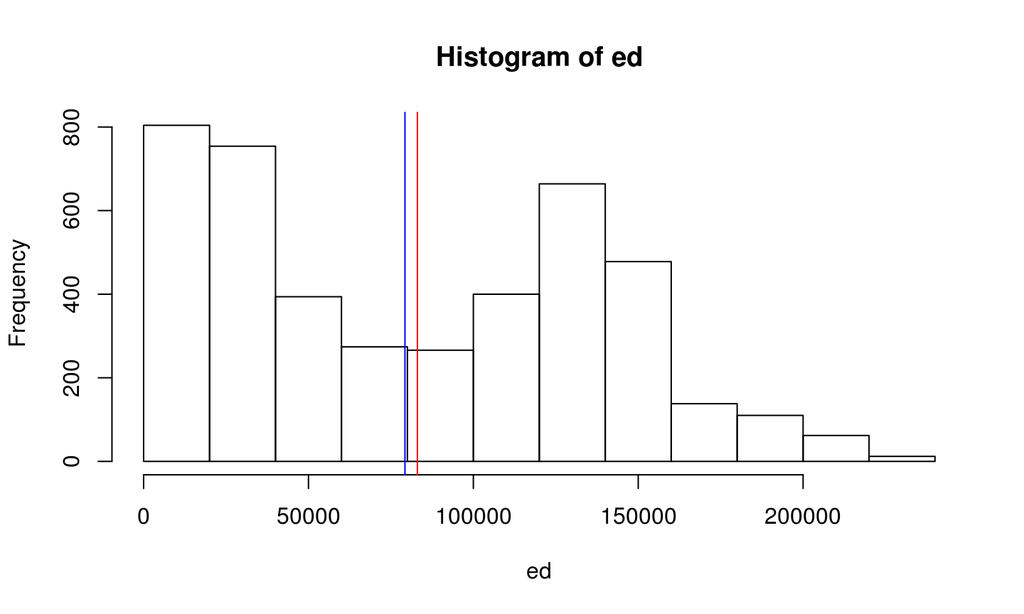

```r
hist(ed)
abline(v = mean(ed[ed>0]), col = "red")
abline(v = median(ed[ed>0]), col = "blue")
```

## Distance analyses in geographic space

Some further questions that might be interesting

```r
mp <- apply(X = ed,
            MARGIN = 2,
            FUN = mean)

tmp <- ed
tmp[tmp==0] <- 9999

cp <- apply(X = tmp,
            MARGIN = 2,
            FUN = min)

sites$mp <- mp
sites@data$cp <- cp
```

What is the mean euclidean distance from a point to its surrounding points (mp)?

What is the closest euclidean distance from a point to its surrounding points (cp)?

**Question:** Why changing 0 to 9999?

## Distance analyses in geographic space

```r
spplot(sites, "cp")
```

[output not shown]

```r
spplot(sites, "mp")
```

[output not shown]

Examples how to use `spplot`: http://rspatial.r-forge.r-project.org/gallery/

## Distance analyses in geographic space

Leaflet in `R`: https://rstudio.github.io/leaflet/

```r
library(leaflet)
tmp <- spTransform(sites, CRSobj = CRS("+init=epsg:4326"))
leaflet(data=tmp$cp) %>%
    addTiles() %>%
    addCircleMarkers(lng = tmp@coords[,1],
                     lat = tmp@coords[,2],
                     radius = tmp$mp/1000,
                     )
```

[output not shown]

## Distance analyses in geographic space

`Mapview` [as alternative to `leaflet`]: http://environmentalinformatics-marburg.github.io/mapview/introduction.html

```r
library(mapview)
mapview(sites, zcol = "mp", legend = TRUE)
```

[interactive chart not shown]

## Distance analyses in geographic space

**Least-cost distances**

- Cost is — like distance — an abstract concept; hence, YOU decide what your costs are (time, energy, ugliness, …)
- Least-cost distance analyses allow to integrate prior knowledge and more complexity into your model.

**There was a discourse at the LAC about least-cost paths (LCP):**

- Opinion 1: LCP follow a **capitalistic** ideology since their aim is the best optimization. They are blind for post-processual ideas
- Opinion 2: LCP do optimize a certain path. But the rules, how they do it, is defined by **parameters** chosen for the model. Hence, they are able to grasp post-processual ideas

## Distance analyses in geographic space

Basic work about least-cost distances and path analyses (usefulness, applicability, problems,…) was/is conducted quite excessively by Irmela Herzog (https://bodendenkmalpflege-lvr.academia.edu/IrmelaHerzog)

## Distance analyses in geographic space

What does it mean?

```r
## km/h
tobler1993a <- function(s){
    6 * exp(-3.5 * abs(s + 0.05))
}
## m/min
tobler1993b <- function(s){
    0.36 * exp(-3.5 * abs(s + 0.05))
}
```

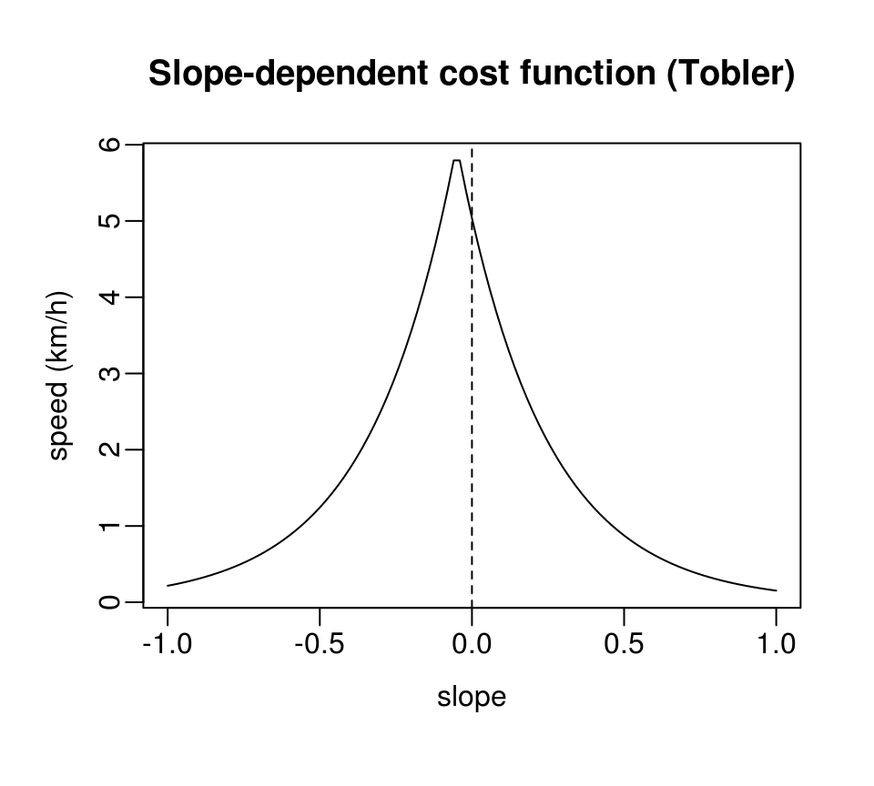

## Distance analyses in geographic space

Technically speaking, there are two different ways how least-cost paths are created

1. create a cost raster
2. accumulate the costs from one of your points of interest
3. "walk" from a target point along the accumulated raster to your starting point (like water flows into a sink)

In `GrassGIS`:

- cost raster
- `r.cost`/`r.walk`
- `r.drain`

## Distance analyses in geographic space

Technically speaking, there are two different ways how least-cost paths are created

In `R`:

1. create cost raster
2. create matrix of cell connections
3. find "cheapest" path between points along cell connections

`gdistance` in `R` a package by Jacob van Etten (https://cran.r-project.org/web/packages/gdistance)

## Distance analyses in geographic space

What are the necessary steps?

1. Create cost surface

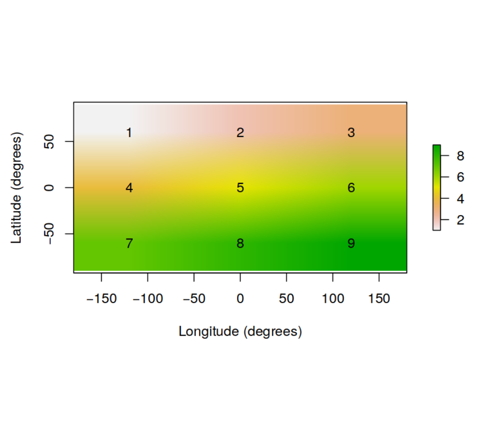

(https://cran.r-project.org/web/packages/gdistance/vignettes/gdistance1.pdf)

## Distance analyses in geographic space

What are the necessary steps?

1. Create cost surface
2. Create transition matrix, i.e. matrix recording connections between cells

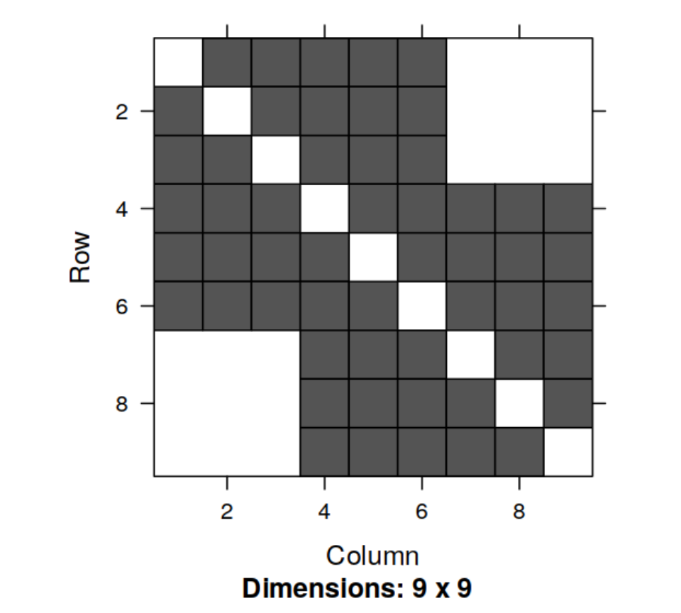

(https://cran.r-project.org/web/packages/gdistance/vignettes/gdistance1.pdf)

## Distance analyses in geographic space

What are the necessary steps?

1. Create cost surface
2. Create transition matrix, i.e. matrix recording connections between cells
3. Transition matrix is filled with conductance, rather than resistance values; hence unconnected cells have value 0 (= no conductance); memory efficient

## Distance analyses in geographic space

What are the necessary steps?

1. Create cost surface
2. Create transition matrix, i.e. matrix recording connections between cells
3. Transition matrix is filled with conductance, rather than resistance values; hence unconnected cells have value 0 (= no conductance); memory efficient
4. Geocorrection of values

## Distance analyses in geographic space

What are the necessary steps?

1. Create cost surface
2. Create transition matrix, i.e. matrix recording connections between cells
3. Transition matrix is filled with conductance, rather than resistance values; hence unconnected cells have value 0 (= no conductance); memory efficient
4. Geocorrection of values
5. Identify adjacent cells

## Distance analyses in geographic space

What are the necessary steps?

1. Create cost surface
2. Create transition matrix, i.e. matrix recording connections between cells
3. Transition matrix is filled with conductance, rather than resistance values; hence unconnected cells have value 0 (= no conductance); memory efficient
4. Geocorrection of values
5. Identify adjacent cells
6. Calculate walking speed for adjacent cells

## Distance analyses in geographic space

What are the necessary steps?

1. Create cost surface
2. Create transition matrix, i.e. matrix recording connections between cells
3. Transition matrix is filled with conductance, rather than resistance values; hence unconnected cells have value 0 (= no conductance); memory efficient
4. Geocorrection of values
5. Identify adjacent cells
6. Calculate walking speed for adjacent cells
7. Geocorrect speed values

## Distance analyses in geographic space

What are the necessary steps?

1. Create cost surface
2. Create transition matrix, i.e. matrix recording connections between cells
3. Transition matrix is filled with conductance, rather than resistance values; hence unconnected cells have value 0 (= no conductance); memory efficient
4. Geocorrection of values
5. Identify adjacent cells
6. Calculate walking speed for adjacent cells
7. Geocorrect speed values
8. Find path using least-cost ("as the wolf runs") or random walk ("drunkard's walk") algorithm

## Distance analyses in geographic space

First we calculate the slope, as this is used as cost

```r
library(raster)
dem <- raster("results/srtm.tif")
dem <- aggregate(x = dem, fact = 10)
slope <- terrain(x = dem,
                 opt = "slope",
                 neighbors = 8,
                 unit = "degrees")
slope <- crop(x = slope,
              y = extent(slope)-1000
              )
```

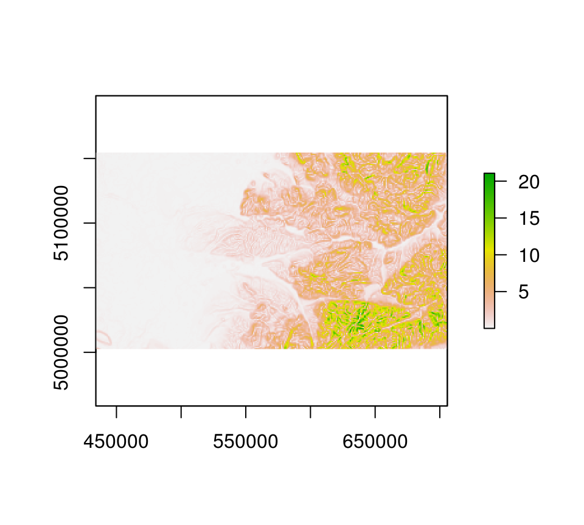

## Distance analyses in geographic space

Now we create the transition object and geocorrect it

```r
library(gdistance)
slope.tran <- transition(x = slope,
                         transitionFunction = mean,
                         directions = 8,
                         symm = TRUE
                         )
slope.geo <- geoCorrection(x = slope.tran, scl = TRUE)
```

To see how the results look like we create a raster stack for easy plotting

```r
slopes <- stack(slope,
                raster(slope.tran),
                raster(slope.geo))
names(slopes) <- c("Slope","Transition","Geocorrection")
```

## Distance analyses in geographic space

To see how the results look like we create a raster stack for easy plotting

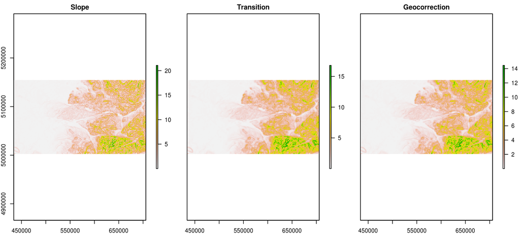

```r
plot(slopes, nr = 1)
```

## Distance analyses in geographic space

Now, the final step. Calculate Tobler's hiking speed, geocorrect again and calculate a shortest path

```r
adj <- adjacent(x = slope,
                cells=1:ncell(slope),
                pairs=TRUE,
                directions=8)
speed <- slope.geo
speed[adj] <-  6 * exp(-3.5 * abs(slope.geo[adj] + 0.05))

speed.geo <- geoCorrection(x = speed, scl=TRUE)

sp1 <- shortestPath(x = speed.geo,
                    origin = sites@coords[4,],
                    goal = sites@coords[50,],
                    output = "SpatialLines")
```

## Distance analyses in geographic space

Now, the final step. Calculate Tobler's hiking speed, geocorrect again and calculate a shortest path

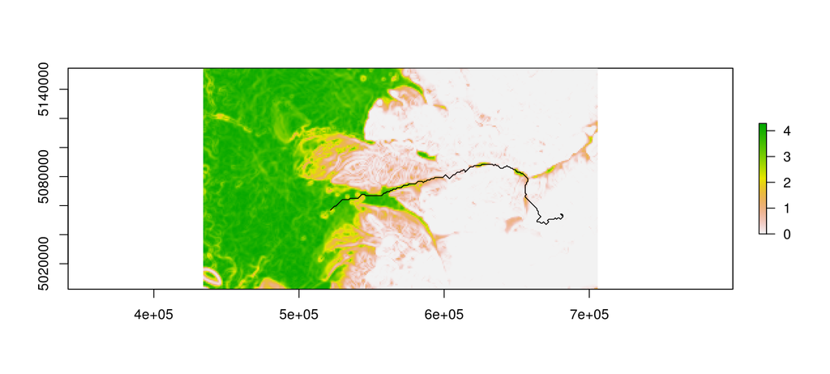

```r
plot(raster(speed.geo))
lines(sp1)
```

## Distance analyses in geographic space

What about the "drunkard's walk"?

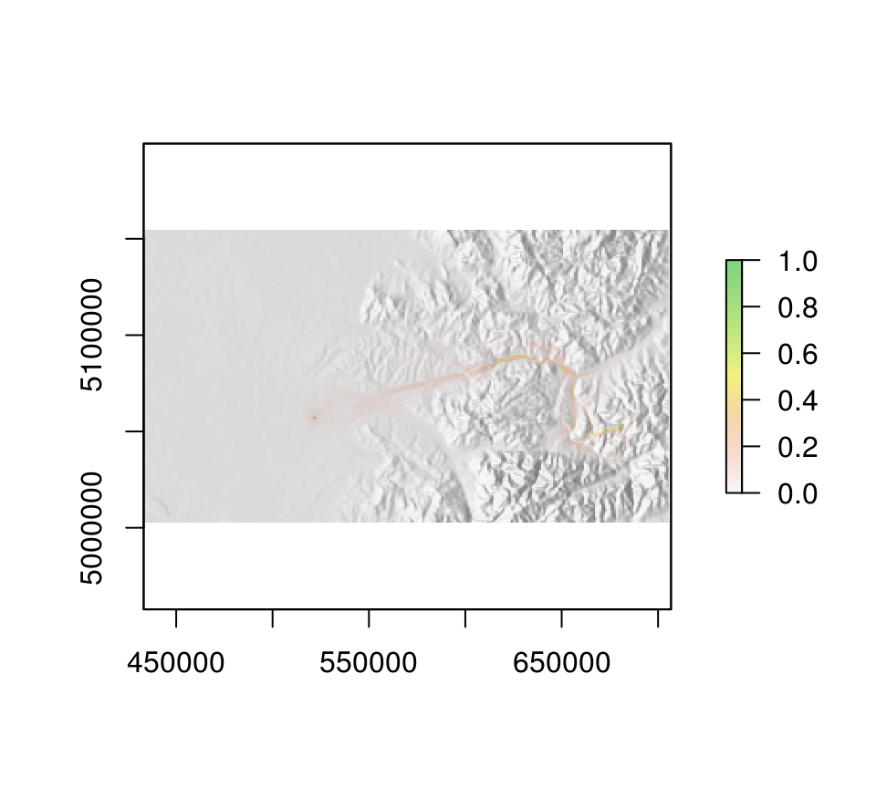

```r
p1 <- passage(x = speed.geo,
              origin = sites@coords[4,],
              goal = sites@coords[50,]#,
              ##theta = .005
              )

hs <-  hillShade(
    slope = terrain(x = dem*10, opt = "slope"),
    aspect = terrain(x = dem, opt = "aspect"),
    angle = 40, direction = 270
)

plot(hs, col=grey(0:100/100), legend=FALSE)
plot(p1, alpha = .5, add=TRUE)#; lines(sp1)
```

## Distance analyses in geographic space

What about the idea of a **prehistoric autobahn**? Run the code and get some coffee (most probably)

```r
xy <- data.frame(X = sites@coords[,1],
                 Y = sites@coords[,2])

rows.xy <- row.names(xy)
sa.rows.xy <- sample(row.names(xy), length(xy$X)/2)
starts <- subset(xy, rows.xy %in% sa.rows.xy)
goals <- subset(xy, !(rows.xy %in% sa.rows.xy))
sg.passages <- brick(slope)

for(i in 1:length(starts$X)) {
    s <- c(starts$X[i],starts$Y[i])
    z <- c(goals$X[i],goals$Y[i])
    sg.passages[[i]] <- passage(x = speed.geo, origin = s, goal = z)
    cat("iteration ", i, " of ", length(starts$X),"\n")
}
```

```
## iteration  1  of  33
## iteration  2  of  33
## iteration  3  of  33
## iteration  4  of  33
## iteration  5  of  33
## iteration  6  of  33
## iteration  7  of  33
## iteration  8  of  33
## iteration  9  of  33
## iteration  10  of  33
## iteration  11  of  33
## iteration  12  of  33
## iteration  13  of  33
## iteration  14  of  33
## iteration  15  of  33
## iteration  16  of  33
## iteration  17  of  33
## iteration  18  of  33
## iteration  19  of  33
## iteration  20  of  33
## iteration  21  of  33
## iteration  22  of  33
## iteration  23  of  33
## iteration  24  of  33
## iteration  25  of  33
## iteration  26  of  33
## iteration  27  of  33
## iteration  28  of  33
## iteration  29  of  33
## iteration  30  of  33
## iteration  31  of  33
## iteration  32  of  33
## iteration  33  of  33
```

```r
sg.passages.sum <- sum(sg.passages)
```

## Distance analyses in geographic space

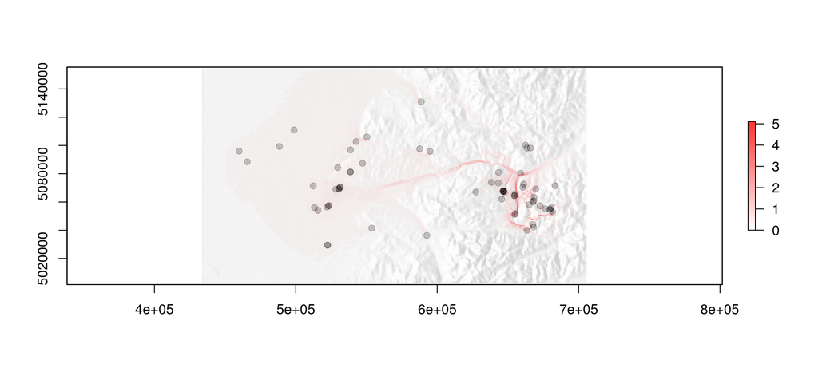